# US_Household_Income

Naeem Chowdhury, Rosa Gradilla

December 2, 2019

## Summary

### About the data:

The dataset originally developed for real estate and business investment research. Income is a vital element when determining both quality and socioeconomic features of a given geographic location. The following data was derived from over +36,000 files and covers 348,893 location records.

### Household & Geographic Statistics:

- Mean Household Income (double)
- Median Household Income (double)
- Standard Deviation of Household Income (double)
- Number of Households (double)
- Square area of land at location (double)
- Square area of water at location (double)

### Geographic Location:

- Longitude (double)
- Latitude (double)
- State Name (character)
- State abbreviated (character)
- State_Code (character)
- County Name (character)
- City Name (character)
- Name of city, town, village or CPD (character)
- Primary, Defines if the location is a track and block group.
- Zip Code (character)
- Area Code (character)

## Exploration (Playground)

### Histograms

Before subsetting our data, we have a strange bimodal distribution of values. There is a second peak all concentrated at an income of $300k.

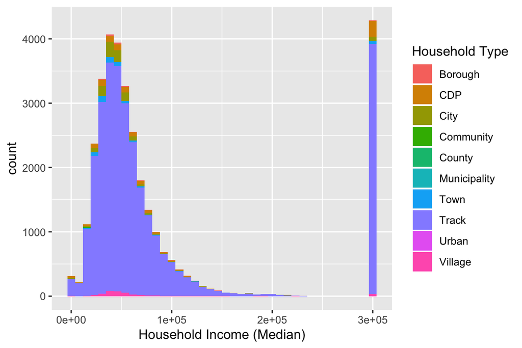

Afterwards, we have a much more natural distribution.

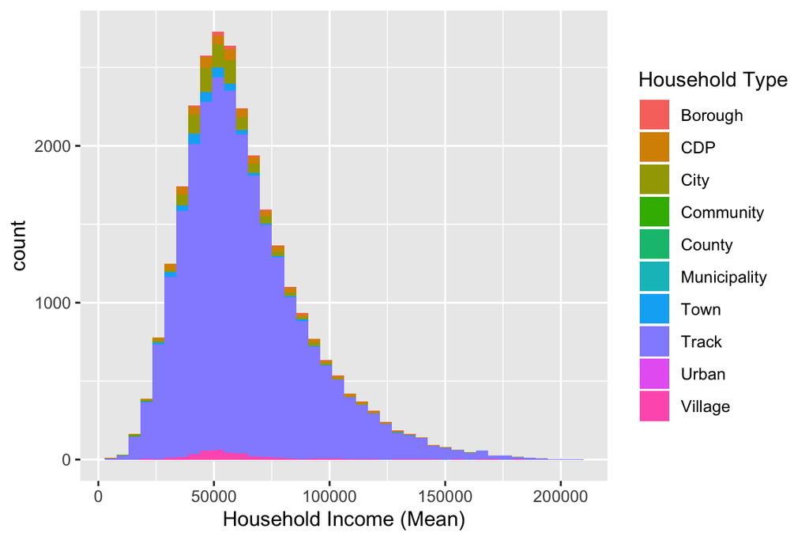

### What’s going on with all the rich people?

There are 4k+ data points which have precisely 300000 dollars as their median income value. This is a data anomaly that messes with our summary statistics, so we decided it would be best to toss them out.

```
## # A tibble: 1 x 1
##       n
##   <int>
## 1  4287
```

## Analysis

### Correlation Matrix

How are the quantitative variables correlated with each other? Since the bulk of our quantitative variables are summary statistics gathered manually about each location, they will naturally have a high correlation with each other.

Naturally, we might ask, do the land area and water area of a location have any relationship with the income of its residents?

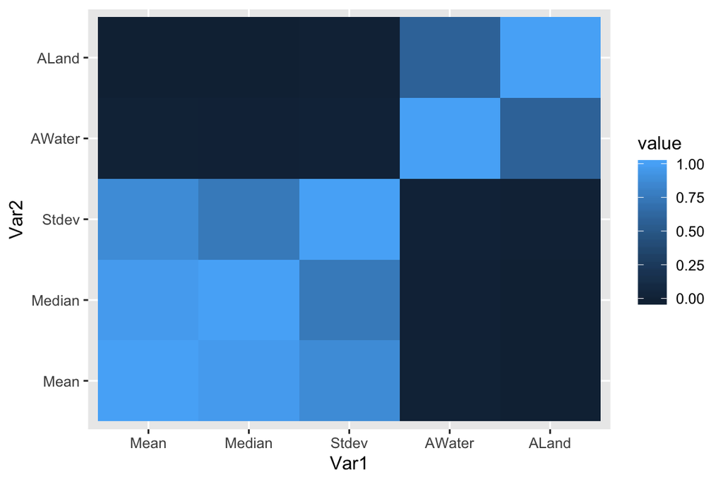

### Scatter Plots and Linear Regressions

At first glance, there doesn’t seem to be much of a relationship between the physical area of a city and the income of the residents. What might happen if we remove outlier values?

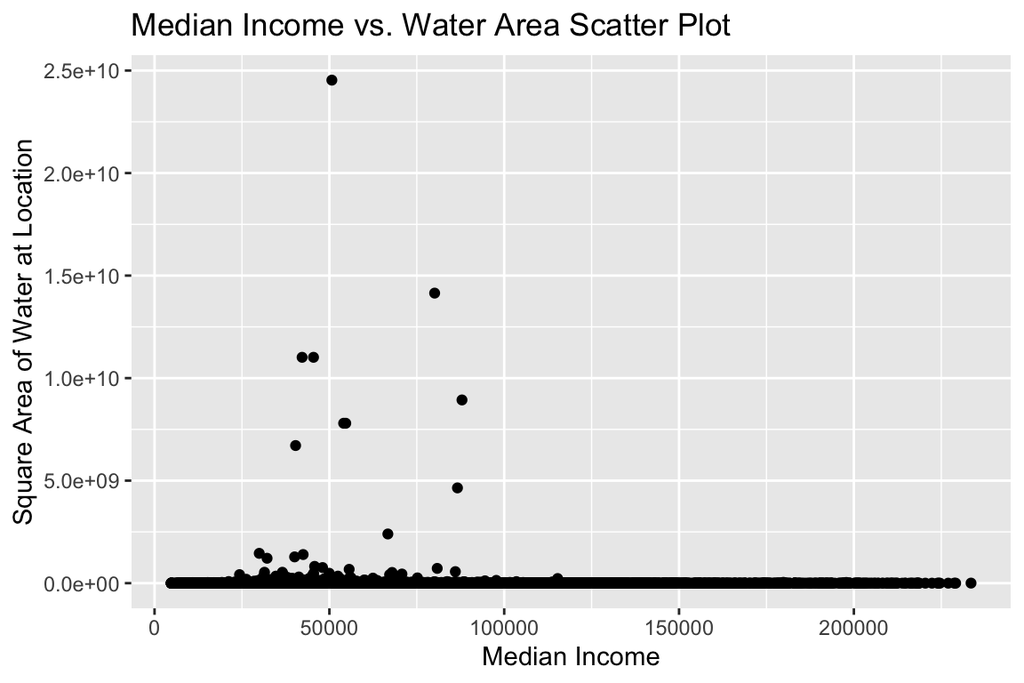

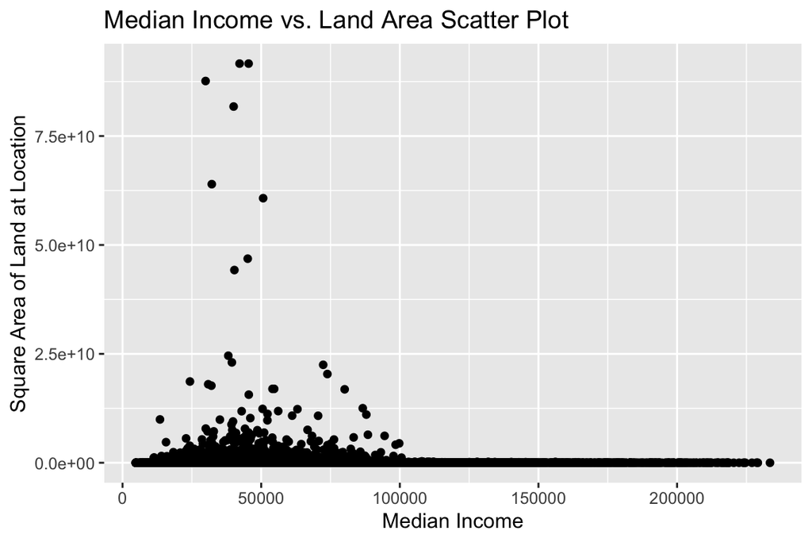

It seems that the correlations we produced in the previous section are a result of outlier values that skew the data. Lets to find out what the outliers are.

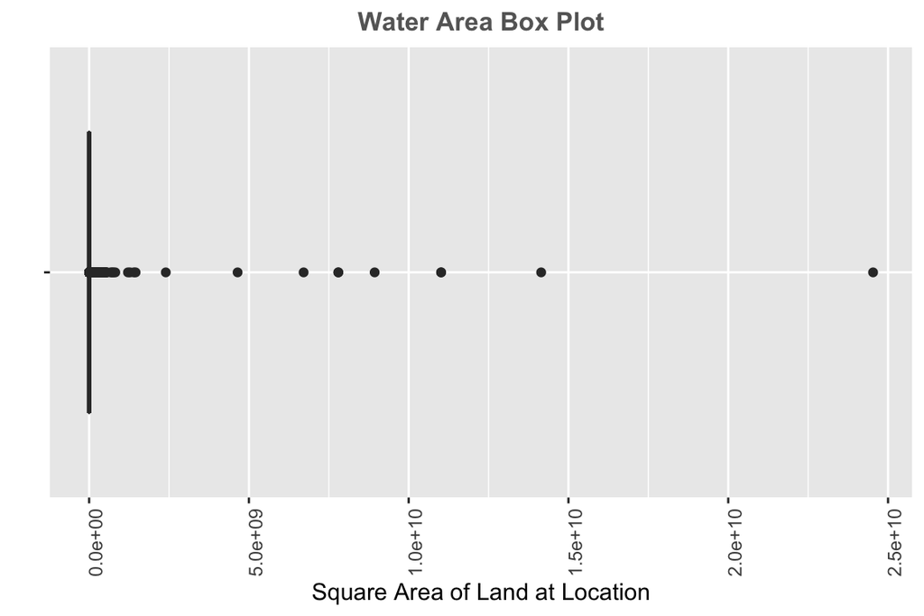

```
## $stats
## [1]       0       0   26971  524548 1309742
```

```
## $stats
## [1]    40326  1872062  5077592 34332073 82994663
```

[figure not shown]

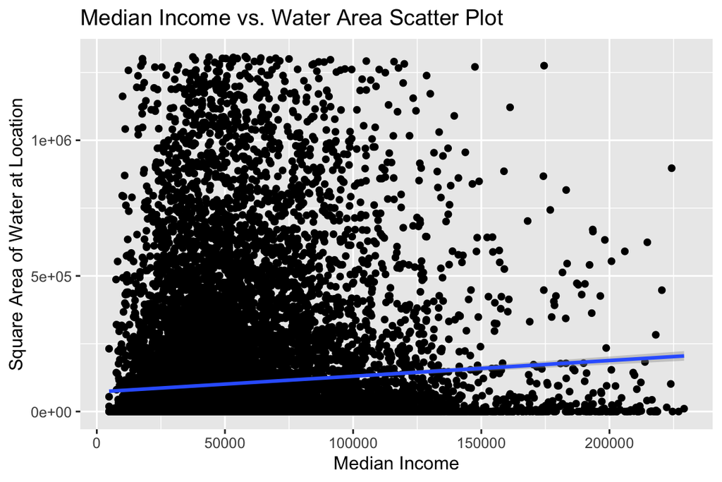

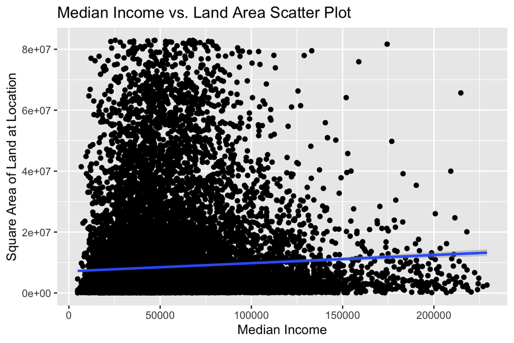

### Correlation matrix without outliers

```
##              Mean     Median      Stdev     AWater      ALand
## Mean   1.00000000 0.96901996 0.87012568 0.08764647 0.05922329
## Median 0.96901996 1.00000000 0.75517401 0.07799200 0.05750698
## Stdev  0.87012568 0.75517401 1.00000000 0.09164240 0.04544672
## AWater 0.08764647 0.07799200 0.09164240 1.00000000 0.37821746
## ALand  0.05922329 0.05750698 0.04544672 0.37821746 1.00000000
```

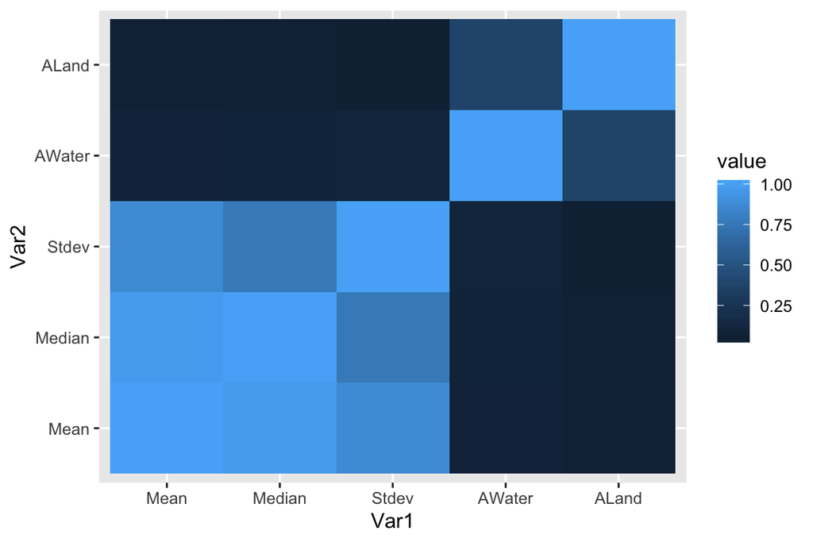

## One-Sample Statistical Inference for Income

Confidence interval for income’s population mean income value.

```
## [1] 53145.03 53812.59
```

```
##
##  One Sample t-test
##
## data:  df_income2$Median
## t = 20.428, df = 27923, p-value < 2.2e-16
## alternative hypothesis: true mean is not equal to 50000
## 95 percent confidence interval:
##  53145.03 53812.59
## sample estimates:
## mean of x
##  53478.81
```

We tested against the null hypothesis mu = 50,000 on a two sided t test. Our confidence interval for population’s median income is [53145.03, 53812.59]. We are 95% confident the true population’s median income falls bewteen our confidence interval 95% of the time. Given that our data came from a random sample and assuming the population’s distribution is approximately normal.

We came up with a null hypothesis claiming the true population’s median income is equal to 50,000, our t-test against this null hypothesis gave us a p-value < 2.2e-16 thus we reject the null hypothesis. This agrees with our confidence interval given that 50,000 is not part of it.

```
## [1] 0.1222492
```

Our effect size is 0.1222492. We witness a relatively small practical effect size.

## Categorical Explanatory Variable

Here we are performing a proportion test for the proportion of median income being lower than 50,000

```
## shaved_income
## below above
## 13954 13962
```

```
##
##  1-sample proportions test with continuity correction
##
## data:  13954 out of 27924, null probability 0.5
## X-squared = 0.0080576, df = 1, p-value = 0.9285
## alternative hypothesis: true p is not equal to 0.5
## 95 percent confidence interval:
##  0.4938316 0.5055955
## sample estimates:
##         p
## 0.4997135
```

Our confidence interval is [0.4938316, 0.5055955]. We tested a null p equal to 0.5. We failed to reject the null hypothesis. A p-value of 0.9285 indicates that the probability of observing our test statistic p = 0.4997135 is 93% given the null-hypothesis is true.

Our effect size is 0.000573, we witness a very small practical effect size.

### Two-sample statistical inference

Two sample: compare means of two population groups: cities and towns

Is there a significant difference between the household incomes in cities and towns?

Ho: mt = mc i.e. there is no difference Ha: mt != mc

```
##
##  Welch Two Sample t-test
##
## data:  city$Median and town$Median
## t = 2.5361, df = 776.45, p-value = 0.0114
## alternative hypothesis: true difference in means is not equal to 0
## 95 percent confidence interval:
##   747.1329 5865.2244
## sample estimates:
## mean of x mean of y
##  47112.28  43806.10
```

Checking assumptions:

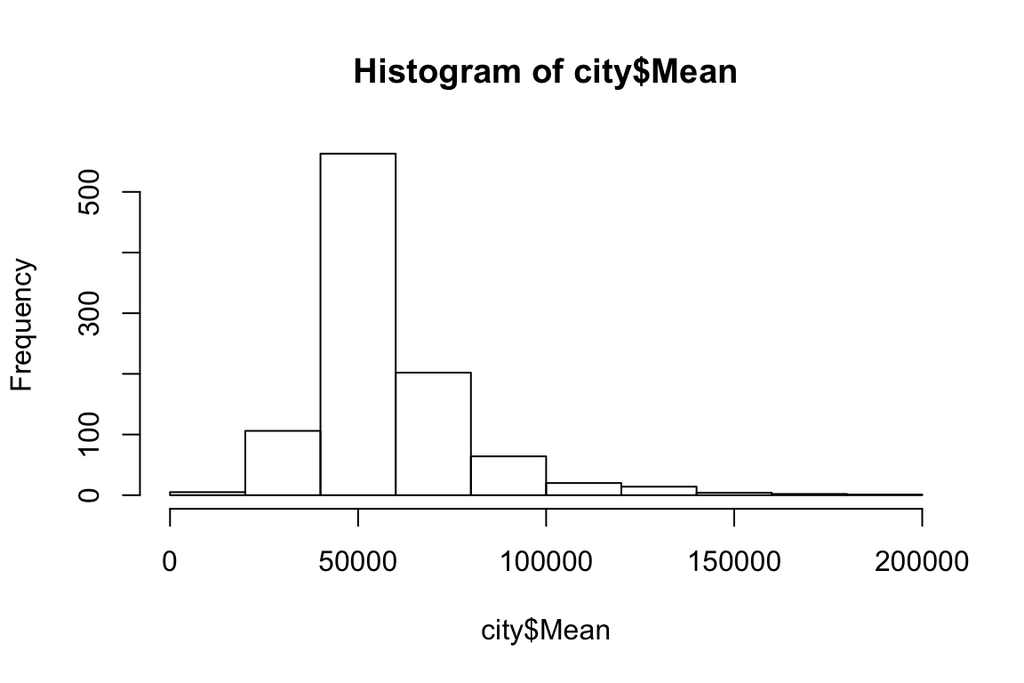

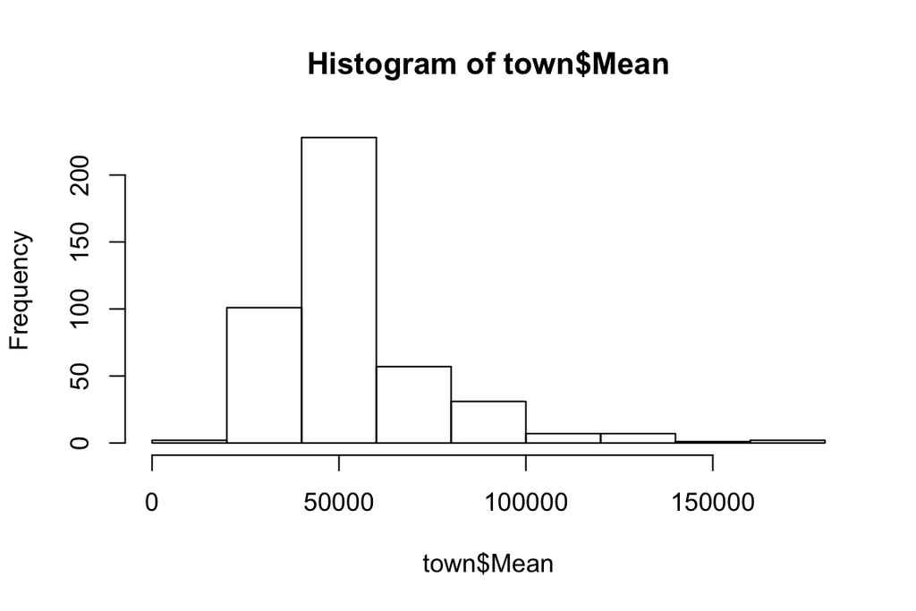

Since both of our groups seem to be slightly skwed, out t-test might not be reliable since it assumes the data is normally distributed.

Effect size:

Our effect size is 0.148239. thus we witness a relatively small effect size.

```
## For a subsample of 10 points: 0.8718
```

```
## [1] " "
```

```
## For a subsample of 50 points: 0.8906
```

```
## [1] " "
```

```
## For a subsample of 100 points: 0.8922
```

```
## [1] " "
```

```
## For a subsample of 1000 points: 0.9057
```

## Bootstrap Simulations

Based on our previous analysis of the quantitative variables, it seems that income is most highly correlated with the water area at the location. We proceed by computing 10,000 bootstrapped simulations of the data.

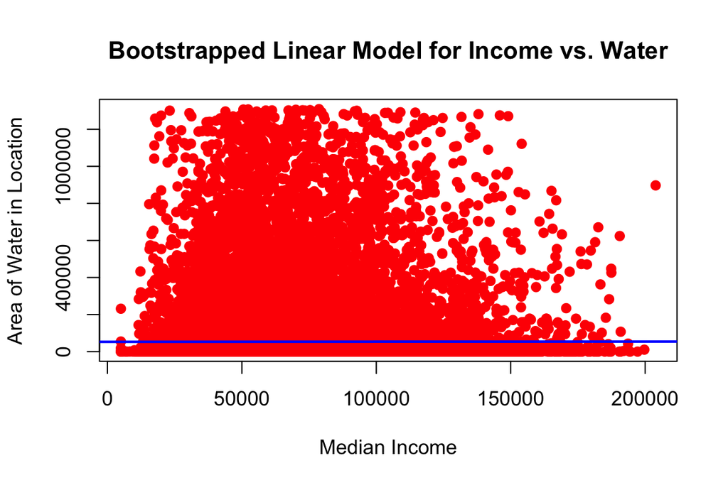